# R Assignment - Estimation

Alexander Thiersch, GWU Intro to Data Science DATS 6101

2022-02-25

# HW Assignment - Estimation

This exercise uses the graduate school admissions dataset from the applicants to a higher-ed institute. The dataset is LogRegAdmit.csv.  
The variables in the dataset are:

- `admit`: 0 or 1 (False or True)
- `gre`: gre score
- `gpa`: grade point average at undergraduate level
- `rank`: the ranking of the applicant’s undergraduate institute, 1, 2, 3, or 4

## Grad School Admissions

### Question 1: Import Dataset

**After importing the dataset as Adata, check the structure. Make sure admit and rank are stored as factors, instead of numeric or integers. (Hint: Use as.factor() function or factor() function).**

```r
#Load Packages
library(ggplot2)


#Importing Dataset
library(readr)
Adata <- read_csv("~/Documents/My6101Work/LogRegAdmit.csv")
#View(Adata)

as.factor(Adata$admit)

as.factor(Adata$rank)

View(Adata)
```

### Question 2: GRE/GPA t-Invervals

**Construct t-intervals for the gre and gpa data for all applicants at 0.80 level and 0.99 level.**

The confidence interval for the gre variable at the 0.80 level is between 580 and 595. The confidence interval for the gre variable at the 0.99 level is between 573 and 603.

The confidence interval for the gpa variable at the 0.80 level is between 3.37 and 3.41. The confidence interval for the gpa variable at the 0.99 level is between 3.34 and 3.44.

```r
#t-interval for gre
gre_ttest80<-t.test(x=Adata$gre,conf.level = .80)
gre_ttest99<-t.test(x=Adata$gre,conf.level = .99)


#t-interval for gpa
gpa_ttest80<-t.test(x=Adata$gpa,conf.level = .80)
gpa_ttest99<-t.test(x=Adata$gpa,conf.level = .99)


gre_ttest80$conf.int
gre_ttest99$conf.int


gpa_ttest80$conf.int
gpa_ttest99$conf.int
```

### Question 3: GRE t-intervals

**Repeat the same calculation for gre in Question 2 but for admitted (1) and rejected (0) separately. (You can subset them first.) Between the admitted and rejected, does the two intervals overlap at 0.80 level? And at 0.99 level?**

The confidence interval for the gre variable of admitted students at the 0.80 level is between 606 and 631. The confidence interval for the gre variable of admitted students at the 0.99 level is between 594 and 644.

The confidence interval for the gre variable of rejected students at the 0.80 level is between 564 and 582. The confidence interval for the gre variable of rejected students at the 0.99 level is between 555 and 591

There is no overlap between the rejected and admitted students at the 0.80 level and 0.99 level confidence intervals.

```r
#Subset data for admitted(1) and rejected students(0)
admit_student<-subset(Adata, admit==1)
reject_student<-subset(Adata, admit==0)

#View(admit_student)
#View(reject_student)

#t-intervals for admitted students
admitgre_ttest80<-t.test(x=admit_student$gre,conf.level = .80)
admitgre_ttest99<-t.test(x=admit_student$gre,conf.level = .99)

admitgre_ttest80$conf.int
admitgre_ttest99$conf.int

#t-intervals for rejected students
rejectgre_ttest80<-t.test(x=reject_student$gre,conf.level = .80)
rejectgre_ttest99<-t.test(x=reject_student$gre,conf.level = .99)

rejectgre_ttest80$conf.int
rejectgre_ttest99$conf.int
```

### Question 4: Boxplots for GRE

**Make (box-) plots showing the gre distribution among applicants from different school rankings for the admitted and rejected separately. Please use ggplot for this. The x-variable should be rank, and the y-variable should be gre.**

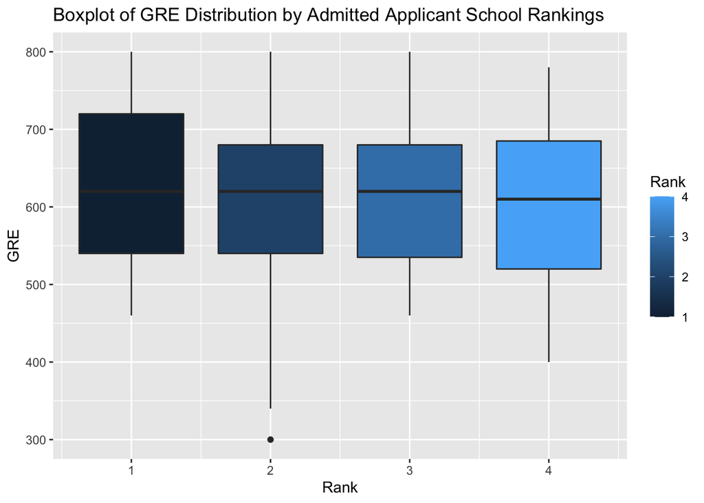

```r
ggplot(admit_student, aes(x=rank, y=gre, group=rank))+geom_boxplot(aes(fill=rank))+
  ggtitle("Boxplot of GRE Distribution by Admitted Applicant School Rankings") + xlab("Rank") + ylab("GRE") + labs(fill="Rank")
```

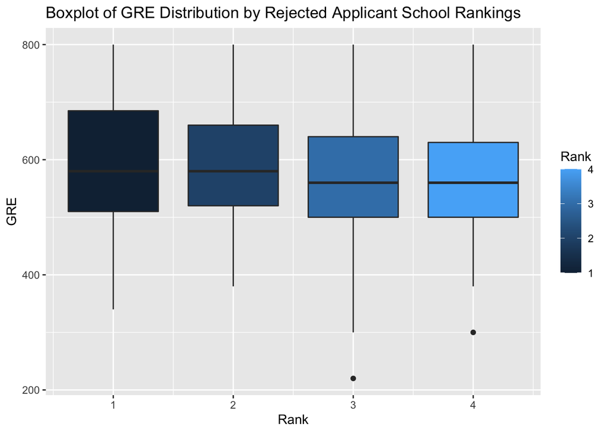

```r
ggplot(reject_student, aes(x=rank, y=gre, group=rank))+geom_boxplot(aes(fill=rank))+
  ggtitle("Boxplot of GRE Distribution by Rejected Applicant School Rankings") + xlab("Rank") + ylab("GRE") + labs(fill="Rank")
```

### Question 5: GPA t-intervals

**Repeat Question 2 and Question 3 for gpa. Do the two groups have t-intervals overlap at 0.80 level? At 0.99 level?**

The confidence interval for the gpa variable of admitted students at the 0.80 level is between 3.45 and 3.53. The confidence interval for the gre variable of admitted students at the 0.99 level is between 3.40 and 3.58.

The confidence interval for the gpa variable of rejected students at the 0.80 level is between 3.31 and 3.37. The confidence interval for the gpa variable of rejected students at the 0.99 level is between 3.28 and 3.40.

There is no overlap between the rejected and admitted students at the 0.80 level.

There is a slight overlap between the rejected and admitted students at the 0.99 level.

```r
#t-intervals for admitted students
admit_ttest80<-t.test(x=admit_student$gpa,conf.level = .80)
admit_ttest99<-t.test(x=admit_student$gpa,conf.level = .99)

admit_ttest80$conf.int
admit_ttest99$conf.int

#t-intervals for rejected students
rejectgpa_ttest80<-t.test(x=reject_student$gpa,conf.level = .80)
rejectgpa_ttest99<-t.test(x=reject_student$gpa,conf.level = .99)

rejectgpa_ttest80$conf.int
rejectgpa_ttest99$conf.int
```

### Question 6: Boxplots for GPA

**Repeat Question 4 for gpa. Make (box-) plots showing the gpa distribution among applicants from different school rankings for the admitted and rejected separately. Again, use ggplot.**

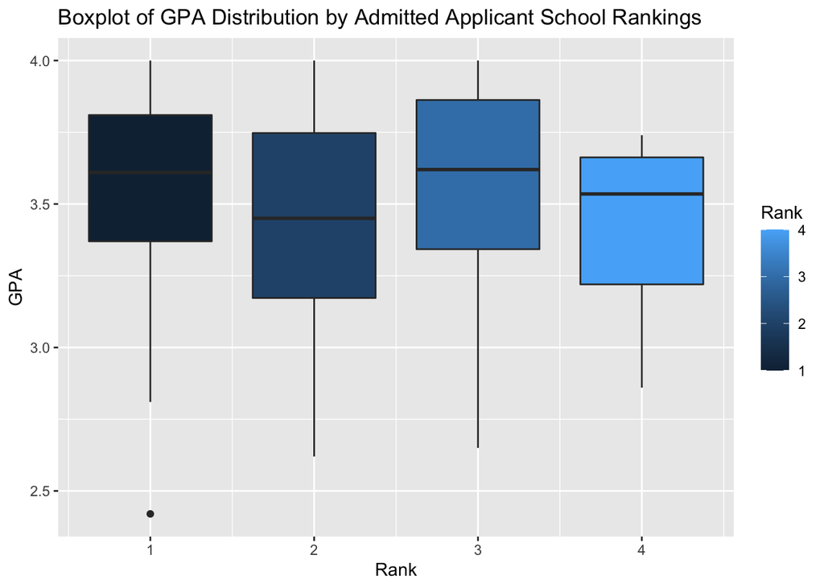

```r
ggplot(admit_student, aes(x=rank, y=gpa, group=rank))+geom_boxplot(aes(fill=rank))+
  ggtitle("Boxplot of GPA Distribution by Admitted Applicant School Rankings") + xlab("Rank") + ylab("GPA") + labs(fill="Rank")
```

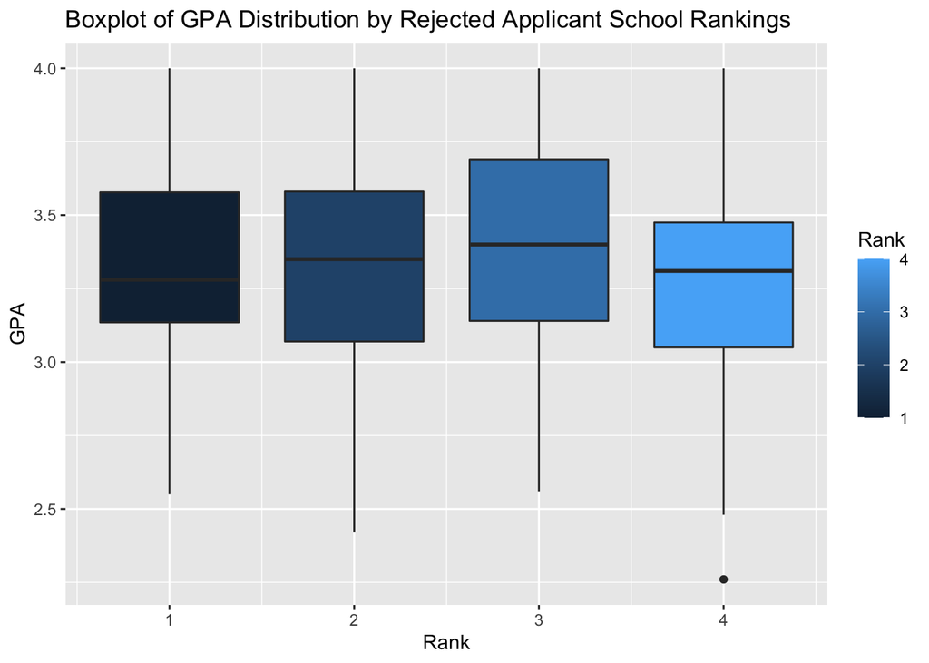

```r
ggplot(reject_student, aes(x=rank, y=gpa, group=rank))+geom_boxplot(aes(fill=rank))+
  ggtitle("Boxplot of GPA Distribution by Rejected Applicant School Rankings") + xlab("Rank") + ylab("GPA") + labs(fill="Rank")
```

### Question 7: GRE/GPA/Rank Effects

**As EDA from the charts and the t-interval calculations you produced, do you observe any potential effects between gre/gpa/rank on admissions? Explain briefly.**

For the GRE data, it appears that a higher rank is associated with a higher GRE score. This is with rank 1 being the highest rank and rank 4 being the lowest rank. However, the median GRE among all ranks of admitted students is relatively similar to one another. This trend is also seen among all the ranks of the rejected students, who share similar median GRE scores. All ranks of admitted students have a median GRE score above 600. All ranks of rejected students have a median GRE score below 600.

For the GPA data, the relationships between GPA, GRE, rank, admissions, and rejections are unclear. A higher school rank is not always associated with a higher median GPA or a higher interquartile range of GPA’s. For example among admitted and rejected students, the rank 3 school has the highest median GPA and a higher interquartile range than all the other ranks. Ranks 1, 3, and 4 of admitted students have a median GPA above 3.5, but, students from a rank 2 school have a median GPA of slightly below 3.5. All ranks of rejected students have a median GPA below 3.5.